# The most destructive natural disasters

Zhang Chi

### Synopsis

By analyzing the raw data and organizing the event types according to the file description. Since most event statistics data appeared after 1993, the focus is on comparing the impact of various events on population health and economic after 1993. During the analysis process, abnormal values in the data were corrected. It was concluded that from 1993 to 2011, the disasters that caused major fatalities were excessive heat, tornadoes, flash floods. The most harmful disasters that caused injuries were tornadoes, floods, and excessive heat. The largest propdmg was caused by hurricanes/typhoons, storm surges/tides, and floods. The largest cropdmg was caused by droughts, floods, and hurricanes/typhoons.

## Data Processing

Load the tidyverse, ggubr packages

```r
knitr::opts_chunk$set(echo = TRUE)
library(tidyverse)
library(ggpubr)
```

Read the original file and filter the data needed. Mainly analyze the number of faralities, injuries and economic damage, select relevant columns.

```r
data <- read_csv(gzfile('repdata_data_StormData.csv.bz2'))
# choose the needed data
col_name <- c('BGN_DATE','EVTYPE','FATALITIES','INJURIES','PROPDMG','PROPDMGEXP','CROPDMG','CROPDMGEXP')
a_data <- data[,col_name]
# check the columns of a_data
summary(a_data)
```

```
##    BGN_DATE            EVTYPE            FATALITIES          INJURIES
##  Length:902297      Length:902297      Min.   :  0.0000   Min.   :   0.0000
##  Class :character   Class :character   1st Qu.:  0.0000   1st Qu.:   0.0000
##  Mode  :character   Mode  :character   Median :  0.0000   Median :   0.0000
##                                        Mean   :  0.0168   Mean   :   0.1557
##                                        3rd Qu.:  0.0000   3rd Qu.:   0.0000
##                                        Max.   :583.0000   Max.   :1700.0000
##     PROPDMG         PROPDMGEXP           CROPDMG         CROPDMGEXP
##  Min.   :   0.00   Length:902297      Min.   :  0.000   Length:902297
##  1st Qu.:   0.00   Class :character   1st Qu.:  0.000   Class :character
##  Median :   0.00   Mode  :character   Median :  0.000   Mode  :character
##  Mean   :  12.06                      Mean   :  1.527
##  3rd Qu.:   0.50                      3rd Qu.:  0.000
##  Max.   :5000.00                      Max.   :990.000
```

When checking the evtype data, it was found that it contained a variety of non-standard types and some errors. There were 977 evtypes before processing, which had a significant impact on data analysis.

```r
length(unique(a_data$EVTYPE))
```

```
## [1] 977
```

Modify some evtypes, standardize the content with the same meaning, replace some modifiers and abbreviations, change some evtypes to formal names according to the description file.

```r
# clean the month summary data
a_data <- a_data[!grepl('summary',a_data$EVTYPE),]
# clean the data, lower the letters
a_data$EVTYPE <- tolower(a_data$EVTYPE)
a_data$PROPDMGEXP <- tolower(a_data$PROPDMGEXP)
a_data$CROPDMGEXP <- tolower(a_data$CROPDMGEXP)

# adjust some same evtype
a_data$EVTYPE <-  gsub('tstm', 'thunderstorm wind',a_data$EVTYPE)
a_data$EVTYPE[grepl('^thunderstorm wind.*[0-9]*',a_data$EVTYPE)] <- 'thunderstorm wind'
a_data$EVTYPE <-  gsub('rains', 'rain', a_data$EVTYPE)
a_data$EVTYPE <-  gsub('floo[o]*ding', 'flood', a_data$EVTYPE)
a_data$EVTYPE <-  gsub('floods', 'flood', a_data$EVTYPE)
a_data$EVTYPE <-  gsub('landslide[s]*', 'debris flow', a_data$EVTYPE)
a_data$EVTYPE <-  gsub('wind wind', 'wind', a_data$EVTYPE)
a_data$EVTYPE <-  gsub('wnd', 'wind', a_data$EVTYPE)
a_data$EVTYPE <-  gsub('winds', 'wind', a_data$EVTYPE)
a_data$EVTYPE[grepl('high wind.*[0-9]+', a_data$EVTYPE)] <- 'high wind'
a_data$EVTYPE[grepl('hail.*[0-9]+', a_data$EVTYPE)] <- 'hail'
a_data$EVTYPE[grepl(' microburst', a_data$EVTYPE)] <- 'thunderstorm wind'
a_data$EVTYPE[grepl('volcanic ash',a_data$EVTYPE)] <- 'volcanic ash'
a_data$EVTYPE[grepl('hurricane [a-z]+$',a_data$EVTYPE)] <- 'hurricane/typhoon'
a_data$EVTYPE[grepl('sml', a_data$EVTYPE)] <- 'heavy rain'
a_data$EVTYPE[grepl('mud[s ]*slide', a_data$EVTYPE)] <- 'mudslide'
a_data$EVTYPE[grepl('urban', a_data$EVTYPE) & !grepl('debris', a_data$EVTYPE)&
                  !grepl('mud', a_data$EVTYPE)] <- 'heavy rain'
a_data$EVTYPE[grepl('^thunderstorm.*w', a_data$EVTYPE)] <- 'thunderstorm wind'
a_data$EVTYPE[grepl('flood.*flash',a_data$EVTYPE)] <- 'flood/flash flood'
a_data$EVTYPE[grepl('hail.*st',a_data$EVTYPE)] <- 'hailstorm'
a_data$EVTYPE[grepl('small stream',a_data$EVTYPE)] <- 'heavy rain'

a_data$EVTYPE[a_data$EVTYPE == 'lake effect snow'] <- 'lake-effect snow'
a_data$EVTYPE[a_data$EVTYPE == 'duststorm'] <- 'dust storm'
a_data$EVTYPE[a_data$EVTYPE == 'dry mircoburst winds' |
                  a_data$EVTYPE == 'thunderstorm'] <- 'thunderstorm wind'
a_data$EVTYPE[a_data$EVTYPE == 'smoke'] <- 'dense smoke'
a_data$EVTYPE[a_data$EVTYPE == 'dam break'] <- 'flash flood'
a_data$EVTYPE[a_data$EVTYPE == 'landspout'] <- 'tornado'
a_data$EVTYPE[a_data$EVTYPE == 'dust devel'] <- 'dust devil'
a_data$EVTYPE[a_data$EVTYPE == 'flash flood/flood'] <- 'flood/flash flood'
a_data$EVTYPE[a_data$EVTYPE == 'flood/flash/flood'] <- 'flood/flash flood'
a_data$EVTYPE[a_data$EVTYPE == 'high winds'] <- 'high wind'
a_data$EVTYPE[a_data$EVTYPE == 'heavy surf/high surf'] <- 'high surf'
a_data$EVTYPE[a_data$EVTYPE == 'thunderstorm winds'] <- 'thunderstorm wind'
a_data$EVTYPE[a_data$EVTYPE == 'thunderstormw'] <- 'thunderstorm wind'
a_data$EVTYPE[a_data$EVTYPE == 'tstm wind'] <- 'thunderstorm wind'
a_data$EVTYPE[a_data$EVTYPE == 'hurricane'] <- 'hurricane/typhoon'
a_data$EVTYPE[a_data$EVTYPE == 'typhoon'] <- 'hurricane/typhoon'
a_data$EVTYPE[a_data$EVTYPE == 'marine tstm wind'] <- 'marine thunderstorm wind'
a_data$EVTYPE[a_data$EVTYPE == 'unseasonably warm'] <- 'heat'
a_data$EVTYPE[a_data$EVTYPE == 'unseasonably warm and dry'] <- 'heat'
a_data$EVTYPE[a_data$EVTYPE == 'record/excessive heat'] <- 'excessive heat'
a_data$EVTYPE[a_data$EVTYPE == 'cold'] <- 'cold/wind chill'
a_data$EVTYPE[a_data$EVTYPE == 'low temperature'] <- 'cold/wind chill'
a_data$EVTYPE[a_data$EVTYPE == 'cold weather'] <- 'cold/wind chill'
a_data$EVTYPE[a_data$EVTYPE == 'extreme windchill'] <- 'extreme cold/wind chill'
a_data$EVTYPE[a_data$EVTYPE == 'extreme cold'] <- 'extreme cold/wind chill'
a_data$EVTYPE[a_data$EVTYPE == 'storm surge'] <- 'storm surge/tide'
a_data$EVTYPE[a_data$EVTYPE == 'wild/forest fire'] <- 'wildfire'
a_data$EVTYPE[a_data$EVTYPE == 'wild fires'] <- 'wildfire'
a_data$EVTYPE[a_data$EVTYPE == 'winter weather/mix'] <- 'winter weather'
a_data$EVTYPE[a_data$EVTYPE == 'winter weather mix'] <- 'winter weather'
a_data$EVTYPE[a_data$EVTYPE == 'rip currents'] <- 'rip current'
a_data$EVTYPE[a_data$EVTYPE == 'winter storms'] <- 'winter storm'
a_data$EVTYPE[a_data$EVTYPE == 'heavy surf'] <- 'high surf'
a_data$EVTYPE[a_data$EVTYPE == 'high surf advisory' |
                  a_data$EVTYPE == 'high surf advisoriesy'] <- 'high surf'
a_data$EVTYPE[a_data$EVTYPE == 'heat waves'] <- 'heat wave'
a_data$EVTYPE[a_data$EVTYPE == 'strong winds'] <- 'strong wind'
a_data$EVTYPE[a_data$EVTYPE == 'tropical storm gordon'] <- 'tropical storm'
a_data$EVTYPE[a_data$EVTYPE == '"volcanic ashfall"'] <- 'volcanic ash'
a_data$EVTYPE[a_data$EVTYPE == '"high surf advisories"'] <- 'high surf'
```

After processing, the number of evtypes was reduced to 651

```r
length(unique(a_data$EVTYPE))
```

```
## [1] 651
```

View the changes of evtypes over time. Before 1993, there were only data for three evtypes:‘tornado’, ‘thunderstorm wind’, and ‘hail’. To ensure the consistency of data, the data was split into before and after 1993, and focus on analyzing the data after 1993.

```r
a_data$date <- mdy_hms(a_data$BGN_DATE)
a_data$year <- year(a_data$date)
unique(a_data$EVTYPE[a_data$year<1993])
```

```
## [1] "tornado"           "thunderstorm wind" "hail"
```

```r
a_data_2011 <- a_data[a_data$year >=1993, ]
a_data_1993 <- a_data[a_data$year < 1993, ]
ev_num <- sort(table(a_data_2011$EVTYPE), decreasing = TRUE)[1:10]
```

Calculate the total number of fatalites and injuries caused by each evtype and save the top ten in descending order.

```r
fatalities <- tapply(a_data_2011$FATALITIES, a_data_2011$EVTYPE, sum)
injuries <- tapply(a_data_2011$INJURIES, a_data_2011$EVTYPE, sum)
fatalities <- sort(fatalities, decreasing = TRUE)[1:10]
injuries <- sort(injuries, decreasing = TRUE)[1:10]
# can also calculate the data before 1993
#fatalities_1993 <- tapply(a_data_1993$FATALITIES, a_data_1993$EVTYPE, sum)
#injuries_1993 <- tapply(a_data_1993$INJURIES, a_data_1993$EVTYPE, sum)
```

Check that if there are some outliers in the data of top ten. Divide the first number by the sum of the evtype, it can be found that in ‘heat’, the largest figure accounts for more than 50 percent of the sum.

```r
for (n in names(fatalities)){
    p <- max(a_data_2011$FATALITIES[a_data_2011$EVTYPE == n],na.rm = TRUE) /
        sum(a_data_2011$FATALITIES[a_data_2011$EVTYPE == n],na.rm = TRUE)
    print(c(n,p))
}
```

```
## [1] "excessive heat" "0.0515625"
## [1] "tornado"            "0.0974706971005552"
## [1] "flash flood"      "0.02002002002002"
## [1] "heat"              "0.596724667349028"
## [1] "lightning"           "0.00612745098039216"
## [1] "rip current"        "0.0104895104895105"
## [1] "flood"              "0.0315126050420168"
## [1] "thunderstorm wind"  "0.0177777777777778"
## [1] "extreme cold/wind chill" "0.0328947368421053"
## [1] "high wind"          "0.0282685512367491"
```

Check the first number of this evtype

```r
max_data <- data.frame()
for (n in c('heat')){
    max_num <- a_data_2011[a_data_2011$EVTYPE == n & a_data_2011$FATALITIES ==
              max(a_data_2011$FATALITIES[a_data_2011$EVTYPE == n],na.rm = TRUE), ]
    max_num <- data[data$BGN_DATE == max_num$BGN_DATE &
                             data$PROPDMG == max_num$PROPDMG &
                             data$FATALITIES == max_num$FATALITIES,]
    max_data <- rbind(max_data,max_num)
}
max_data
```

```
## # A tibble: 1 × 37
##   STATE__ BGN_DATE   BGN_TIME TIME_ZONE COUNTY COUNTYNAME STATE EVTYPE BGN_RANGE
##     <dbl> <chr>      <chr>    <chr>      <dbl> <chr>      <chr> <chr>      <dbl>
## 1      17 7/12/1995… 1100     CST            0 ILZ003>00… IL    HEAT           0
## # ℹ 28 more variables: BGN_AZI <chr>, BGN_LOCATI <chr>, END_DATE <chr>,
## #   END_TIME <chr>, COUNTY_END <dbl>, COUNTYENDN <lgl>, END_RANGE <dbl>,
## #   END_AZI <chr>, END_LOCATI <chr>, LENGTH <dbl>, WIDTH <dbl>, F <dbl>,
## #   MAG <dbl>, FATALITIES <dbl>, INJURIES <dbl>, PROPDMG <dbl>,
## #   PROPDMGEXP <chr>, CROPDMG <dbl>, CROPDMGEXP <chr>, WFO <chr>,
## #   STATEOFFIC <chr>, ZONENAMES <chr>, LATITUDE <dbl>, LONGITUDE <dbl>,
## #   LATITUDE_E <dbl>, LONGITUDE_ <dbl>, REMARKS <chr>, REFNUM <dbl>
```

```r
for (n in names(injuries)){
    p <- max(a_data_2011$INJURIES[a_data_2011$EVTYPE == n],na.rm = TRUE) /
        sum(a_data_2011$INJURIES[a_data_2011$EVTYPE == n],na.rm = TRUE)
    print(c(n,p))
}
```

```
## [1] "tornado"            "0.0493350493350493"
## [1] "flood"             "0.117802974525107"
## [1] "excessive heat"     "0.0795402298850575"
## [1] "thunderstorm wind"  "0.0112721417069243"
## [1] "lightning"           "0.00975143403441683"
## [1] "heat"              "0.108644307982995"
## [1] "ice storm"         "0.793924050632911"
## [1] "flash flood"        "0.0840336134453782"
## [1] "wildfire"           "0.0933997509339975"
## [1] "high wind"          "0.0618055555555556"
```

Check the first number of this evtype

```r
max_data <- data.frame()
for (n in c('ice storm')){
    max_num <- a_data_2011[a_data_2011$EVTYPE == n & a_data_2011$INJURIES ==
              max(a_data_2011$INJURIES[a_data_2011$EVTYPE == n],na.rm = TRUE), ]
    max_num <- data[data$BGN_DATE == max_num$BGN_DATE &
                             data$PROPDMG == max_num$PROPDMG &
                             data$FATALITIES == max_num$FATALITIES,]
    max_data <- rbind(max_data,max_num)
}
max_data
```

```
## # A tibble: 1 × 37
##   STATE__ BGN_DATE   BGN_TIME TIME_ZONE COUNTY COUNTYNAME STATE EVTYPE BGN_RANGE
##     <dbl> <chr>      <chr>    <chr>      <dbl> <chr>      <chr> <chr>      <dbl>
## 1      39 2/8/1994 … 0500     EST            0 OHZ42>088  OH    ICE S…         0
## # ℹ 28 more variables: BGN_AZI <chr>, BGN_LOCATI <chr>, END_DATE <chr>,
## #   END_TIME <chr>, COUNTY_END <dbl>, COUNTYENDN <lgl>, END_RANGE <dbl>,
## #   END_AZI <chr>, END_LOCATI <chr>, LENGTH <dbl>, WIDTH <dbl>, F <dbl>,
## #   MAG <dbl>, FATALITIES <dbl>, INJURIES <dbl>, PROPDMG <dbl>,
## #   PROPDMGEXP <chr>, CROPDMG <dbl>, CROPDMGEXP <chr>, WFO <chr>,
## #   STATEOFFIC <chr>, ZONENAMES <chr>, LATITUDE <dbl>, LONGITUDE <dbl>,
## #   LATITUDE_E <dbl>, LONGITUDE_ <dbl>, REMARKS <chr>, REFNUM <dbl>
```

Process the data in the column ‘PROPDMG’ and ‘PROPDMGEXP’, delete the invalid data, calculate the total property damage. And save the top ten in descending order.

```r
a_data_2011$PROPDMGEXP[a_data_2011$PROPDMGEXP=='k'] <- 3
a_data_2011$PROPDMGEXP[a_data_2011$PROPDMGEXP=='m'] <- 6
a_data_2011$PROPDMGEXP[a_data_2011$PROPDMGEXP=='b'] <- 9

prop_data <- a_data_2011[!(a_data_2011$PROPDMGEXP=='+'|a_data_2011$PROPDMGEXP=='?'|
a_data_2011$PROPDMGEXP=='-'|a_data_2011$PROPDMGEXP=='h')|is.na(a_data_2011$PROPDMGEXP),]
prop_data$PROPDMGEXP[is.na(prop_data$PROPDMGEXP)] = 0
prop_data$PROPDMGEXP <- as.numeric(prop_data$PROPDMGEXP)
prop_data$totaldmg <- prop_data$PROPDMG * (10 ^ prop_data$PROPDMGEXP)

prop_dmg <- tapply(prop_data$totaldmg, prop_data$EVTYPE, sum)
prop_dmg <- sort(prop_dmg, decreasing = TRUE)[1:10]
```

Check that if there are some outliers in the data of top ten. Divide the first number by the sum propdmg of the evtype, it can be found that in ‘flood’, ‘storm surge/tide’, ‘tropical storm’, ‘winter storm’, the largest figure accounts for more than 60 percent of the sum.

```r
for (n in names(prop_dmg)){
    p <- max(prop_data$totaldmg[prop_data$EVTYPE == n],na.rm = TRUE) /
        sum(prop_data$totaldmg[prop_data$EVTYPE == n],na.rm = TRUE)
    print(c(n,p))
}
```

```
## [1] "flood"             "0.794349449444751"
## [1] "hurricane/typhoon" "0.198577618871539"
## [1] "storm surge/tide"  "0.652562912693921"
## [1] "tornado"           "0.106265130021978"
## [1] "flash flood"        "0.0583423148519324"
## [1] "hail"              "0.114388707606974"
## [1] "thunderstorm wind"  "0.0751686431051139"
## [1] "wildfire"          "0.178762033589744"
## [1] "tropical storm"    "0.668450017762923"
## [1] "winter storm"      "0.747496195973545"
```

Check the first number of these evtype, the flood caused $115B propdamage can’t be found by searching the internet. This data was an error.

```r
max_data <- data.frame()
for (n in c('flood', 'storm surge/tide', 'tropical storm', 'winter storm')){
    max_num <- prop_data[prop_data$EVTYPE == n & prop_data$totaldmg ==
              max(prop_data$totaldmg[prop_data$EVTYPE == n],na.rm = TRUE), ]
    max_num <- data[data$BGN_DATE == max_num$BGN_DATE &
                             data$PROPDMG == max_num$PROPDMG &
                             data$FATALITIES == max_num$FATALITIES,]
    max_data <- rbind(max_data,max_num)
}
max_data
```

```
## # A tibble: 4 × 37
##   STATE__ BGN_DATE   BGN_TIME TIME_ZONE COUNTY COUNTYNAME STATE EVTYPE BGN_RANGE
##     <dbl> <chr>      <chr>    <chr>      <dbl> <chr>      <chr> <chr>      <dbl>
## 1       6 1/1/2006 … 12:00:0… PST           55 NAPA       CA    FLOOD          0
## 2      22 8/29/2005… 02:00:0… CST           40 LAZ040 - … LA    STORM…         0
## 3      48 6/5/2001 … 01:00:0… CST          163 TXZ163>16… TX    TROPI…         0
## 4       1 3/12/1993… 2200     CST            0 ALZ001>018 AL    WINTE…         0
## # ℹ 28 more variables: BGN_AZI <chr>, BGN_LOCATI <chr>, END_DATE <chr>,
## #   END_TIME <chr>, COUNTY_END <dbl>, COUNTYENDN <lgl>, END_RANGE <dbl>,
## #   END_AZI <chr>, END_LOCATI <chr>, LENGTH <dbl>, WIDTH <dbl>, F <dbl>,
## #   MAG <dbl>, FATALITIES <dbl>, INJURIES <dbl>, PROPDMG <dbl>,
## #   PROPDMGEXP <chr>, CROPDMG <dbl>, CROPDMGEXP <chr>, WFO <chr>,
## #   STATEOFFIC <chr>, ZONENAMES <chr>, LATITUDE <dbl>, LONGITUDE <dbl>,
## #   LATITUDE_E <dbl>, LONGITUDE_ <dbl>, REMARKS <chr>, REFNUM <dbl>
```

delete the error data from the prop_data, and save the new top ten in descending order.

```r
prop_data <- prop_data[!(prop_data$EVTYPE == 'flood' & prop_data$totaldmg ==
              max(prop_data$totaldmg[prop_data$EVTYPE == 'flood'],na.rm = TRUE)), ]
prop_dmg <- tapply(prop_data$totaldmg, prop_data$EVTYPE, sum)
prop_dmg <- sort(prop_dmg, decreasing = TRUE)[1:10]
```

Process the data in the column ‘CROPDMG’ and ‘CROPDMGEXP’, delete the invalid data, calculate the total crop damage. And save the top ten in descending order.

```r
prop_data$CROPDMGEXP[prop_data$CROPDMGEXP=='k'] <- 3
prop_data$CROPDMGEXP[prop_data$CROPDMGEXP=='m'] <- 6
prop_data$CROPDMGEXP[prop_data$CROPDMGEXP=='b'] <- 9
damage_data <- prop_data[!prop_data$CROPDMGEXP=='?'|is.na(prop_data$CROPDMGEXP),]
damage_data$CROPDMGEXP[is.na(damage_data$CROPDMGEXP)] = 0
damage_data$CROPDMGEXP <- as.numeric(damage_data$CROPDMGEXP)
damage_data$ctotaldmg <- damage_data$CROPDMG * (10 ^ damage_data$CROPDMGEXP)

crop_dmg <- tapply(damage_data$ctotaldmg, damage_data$EVTYPE, sum)
crop_dmg <- sort(crop_dmg, decreasing = TRUE)[1:10]
```

Check the crop damage data like the prop damage above.

```r
for (n in names(crop_dmg)){
    p <- max(damage_data$ctotaldmg[damage_data$EVTYPE == n],na.rm = TRUE) /
        sum(damage_data$ctotaldmg[damage_data$EVTYPE == n],na.rm = TRUE)
    print(c(n,p))
}
```

```
## [1] "drought"            "0.0715688156348662"
## [1] "flood"              "0.0886780487484339"
## [1] "hurricane/typhoon" "0.27424040945873"
## [1] "river flood"       "0.988633874076517"
## [1] "ice storm"        "0.99559677414698"
## [1] "hail"               "0.0231325086675288"
## [1] "flash flood"     "0.1392337680316"
## [1] "extreme cold/wind chill" "0.44811255143708"
## [1] "thunderstorm wind" "0.040802370854074"
## [1] "frost/freeze"      "0.261381520143742"
```

Check the data from ‘river flood’ and ‘ice storm’, there is no error.

```r
max_data <- data.frame()
for (n in c('ice storm', 'river flood')){
    max_num <- damage_data[damage_data$EVTYPE == n & damage_data$ctotaldmg ==
              max(damage_data$ctotaldmg[damage_data$EVTYPE == n],na.rm = TRUE), ]
    max_num <- data[data$BGN_DATE == max_num$BGN_DATE &
                             data$CROPDMG == max_num$CROPDMG &
                             data$PROPDMG == max_num$PROPDMG,]
    max_data <- rbind(max_data,max_num)
}
max_data
```

```
## # A tibble: 2 × 37
##   STATE__ BGN_DATE   BGN_TIME TIME_ZONE COUNTY COUNTYNAME STATE EVTYPE BGN_RANGE
##     <dbl> <chr>      <chr>    <chr>      <dbl> <chr>      <chr> <chr>      <dbl>
## 1      28 2/9/1994 … 0000     CST            0 MSZ001 - … MS    ICE S…         0
## 2      17 8/31/1993… 0000     CST            1 ADAMS, CA… IL    RIVER…         0
## # ℹ 28 more variables: BGN_AZI <chr>, BGN_LOCATI <chr>, END_DATE <chr>,
## #   END_TIME <chr>, COUNTY_END <dbl>, COUNTYENDN <lgl>, END_RANGE <dbl>,
## #   END_AZI <chr>, END_LOCATI <chr>, LENGTH <dbl>, WIDTH <dbl>, F <dbl>,
## #   MAG <dbl>, FATALITIES <dbl>, INJURIES <dbl>, PROPDMG <dbl>,
## #   PROPDMGEXP <chr>, CROPDMG <dbl>, CROPDMGEXP <chr>, WFO <chr>,
## #   STATEOFFIC <chr>, ZONENAMES <chr>, LATITUDE <dbl>, LONGITUDE <dbl>,
## #   LATITUDE_E <dbl>, LONGITUDE_ <dbl>, REMARKS <chr>, REFNUM <dbl>
```

Adding the crop damage with prop damage, calculate the total damage. Save the most ten.

```r
damage_data$damage <- damage_data$totaldmg + damage_data$ctotaldmg
dmg <- tapply(damage_data$damage, damage_data$EVTYPE, sum)
dmg <- sort(dmg, decreasing = TRUE)[1:10]
```

## Result

Show the result of the most ten of fatalites, injuries, prop and crop damage.

```r
fatalities <- data.frame(fatalities)
injuries <- data.frame(injuries)
prop_dmg <- data.frame(prop_dmg)
crop_dmg <- data.frame(crop_dmg)
dmg <- data.frame(dmg)
print('The most fatalities:')
```

```
## [1] "The most fatalities:"
```

```r
print(fatalities)
```

```
##                         fatalities
## excessive heat                1920
## tornado                       1621
## flash flood                    999
## heat                           977
## lightning                      816
## rip current                    572
## flood                          476
## thunderstorm wind              450
## extreme cold/wind chill        304
## high wind                      283
```

```r
print('The most injuries:')
```

```
## [1] "The most injuries:"
```

```r
print(injuries)
```

```
##                   injuries
## tornado              23310
## flood                 6791
## excessive heat        6525
## thunderstorm wind     6210
## lightning             5230
## heat                  2117
## ice storm             1975
## flash flood           1785
## wildfire              1606
## high wind             1440
```

```r
print('The most damage of property:')
```

```
## [1] "The most damage of property:"
```

```r
print(prop_dmg)
```

```
##                      prop_dmg
## hurricane/typhoon 85256335010
## storm surge/tide  47964724000
## flood             29772555807
## tornado           26349189047
## flash flood       17140218083
## hail              15735819013
## thunderstorm wind  9977564700
## wildfire           8391043500
## tropical storm     7704390550
## winter storm       6688997251
```

```r
print('The most damage of crop:')
```

```
## [1] "The most damage of crop:"
```

```r
print(crop_dmg)
```

```
##                            crop_dmg
## drought                 13972566000
## flood                    5638373950
## hurricane/typhoon        5506117800
## river flood              5057484000
## ice storm                5022113500
## hail                     3026044473
## flash flood              1436433150
## extreme cold/wind chill  1330023000
## thunderstorm wind        1225418988
## frost/freeze             1094186000
```

```r
print('The most damage:')
```

```
## [1] "The most damage:"
```

```r
print(dmg)
```

```
##                           dmg
## hurricane/typhoon 90762452810
## storm surge/tide  47965579000
## flood             35410929757
## tornado           26764142317
## hail              18761863486
## flash flood       18576651233
## drought           15018672000
## thunderstorm wind 11202902688
## river flood       10292723500
## ice storm          8967041360
```

Figure the first ten evtypes are most harmful to human.

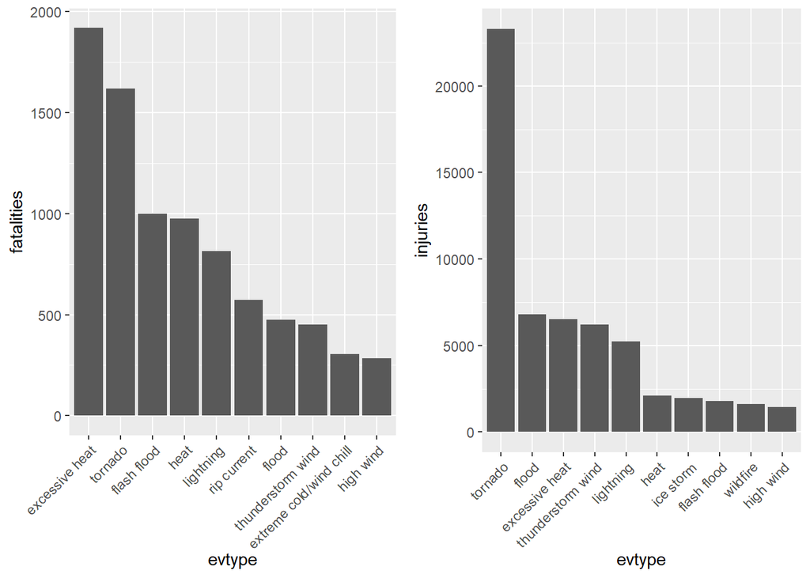

```r
fatalities$evtype <- factor(rownames(fatalities),
                          levels = rownames(fatalities))
p1 <- ggplot(data = fatalities,
       aes(x = evtype, y=fatalities)) + geom_col() +
    theme(axis.text.x = element_text(angle = 45, hjust =1, vjust = 1))
injuries$evtype <- factor(rownames(injuries),
                          levels = rownames(injuries))
p2 <- ggplot(data = injuries,
       aes(x = evtype, y=injuries)) + geom_col() +
    theme(axis.text.x = element_text(angle = 45, hjust =1, vjust = 1))
ggarrange(p1, p2)
```

From the figures above, the disasters that caused major fatalities were excessive heat, tornadoes, flash floods. The most harmful disasters that caused injuries were tornadoes, floods, and excessive heat. And tornado causes far more injuries than other types.

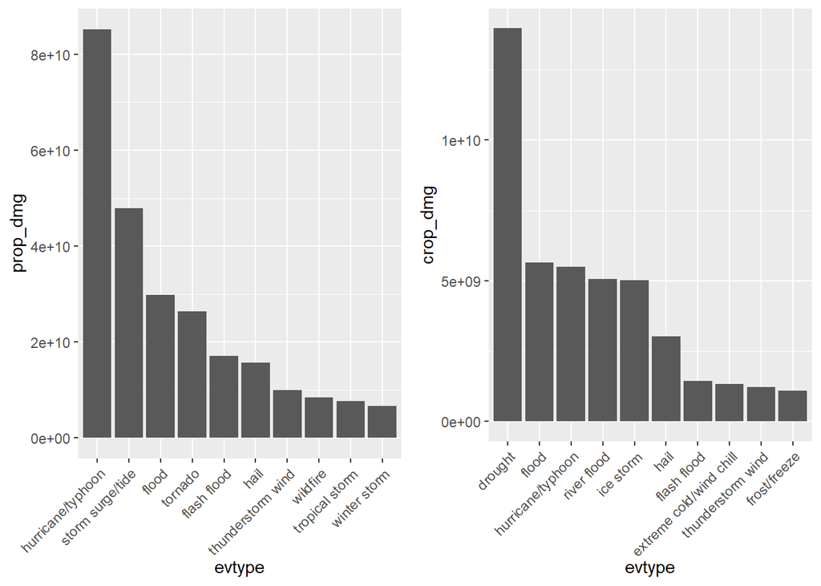

```r
prop_dmg$evtype <- factor(rownames(prop_dmg),
                          levels = rownames(prop_dmg))
p1 <- ggplot(data = prop_dmg,
       aes(x = evtype, y=prop_dmg)) + geom_col() +
    theme(axis.text.x = element_text(angle = 45, hjust =1, vjust = 1))
crop_dmg$evtype <- factor(rownames(crop_dmg),
                          levels =rownames(crop_dmg) )
p2<- ggplot(data = crop_dmg,
       aes(x = evtype, y=crop_dmg)) + geom_col() +
    theme(axis.text.x = element_text(angle = 45, hjust =1, vjust = 1))
ggarrange(p1, p2)
```

From the figures above, the largest propdmg was caused by hurricanes/typhoons, storm surges/tides, and floods. The largest cropdmg was caused by droughts, floods, and hurricanes/typhoons. And drought causes far more cropdmg than other types.